# Green Crab in NS

# What is Rmarkdown

Rmarkdown is a form of literate programming that mixes R and markdown. First lets learn a little about markdown. Markdown is a human readable language with tags that define special formatting elements use to format documents. As you saw, when we render (i.e. knit) this document, we can get an html, pdf, or word document. This means you can make a whole report/manuscript reproducible including the text.

Notice that instead of octothorpes (#) being used as comments in markdown, they are titles

# Title

## Main section

### Sub-section

#### Sub-sub section

You can also have special formatting for text:

**bold** *italics* `code-type`

Additionally, R functions and code do nothing (yet):

mean(c(2,3,4))

… nothing! Until you place things in an R chunk:

```r
mean(c(2,3,4))
```

```
## [1] 3
```

Will by default display the code and the output. You can hide the code in the rendered version:

```
## [1] 3
```

```
## this is a message
```

or you can hide the output:

```r
#hides output in the rendered version
mean(c(2,3,4))
message("this is a message")
```

```
## this is a message
```

Can click “insert” to put in the ticks for code!

or you can also hide messages:

```r
mean(c(2,3,4))
```

```
## [1] 3
```

```r
message("this is a message")
#however, code is showing so you'll see the code to create the message
```

This makes these types of documents extremely responsive to changes or updates in data. An extremely powerful tool in your ‘reproducibility’ tool belt!

# Green Crab reporting

Suppose I want to create a reproducible report about the extent of the European green crab invasion in Nova Scotia. Let also pretend the report starts HERE, because we ran some R code above and didn’t yet load our packages which should always happen at the top of the script, but you needed to learn about Rmarkdown first so I made an exception. We’re also hiding all of this because we don’t need that in the report!

Cool right!

Now let’s make a quick basemap:

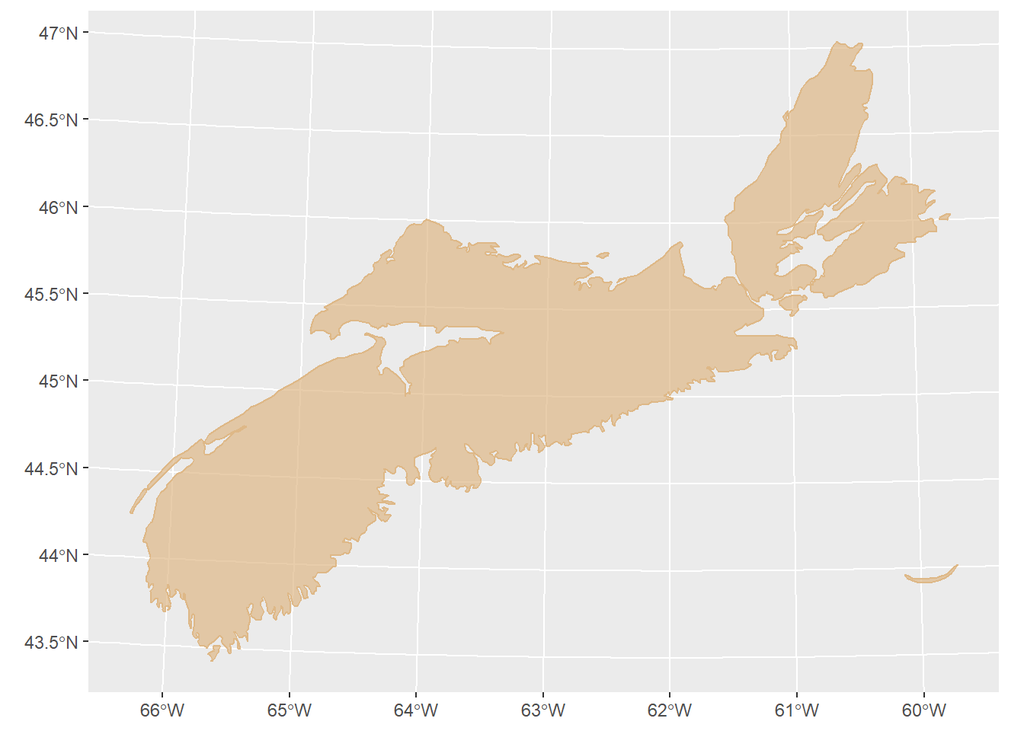

Now let’s get some green crab data from [OBIS](https://obis.org/). You can query by species scientific name and spatial geometry in text format. Our `NS` polygon is too complicated, so let’s make a box around `NS`

```r
txt_geom <- NS %>%
  st_transform(latlong) %>% # transform back to latlong
  st_bbox() %>%             # get bounding box
  st_as_sfc() %>%           # convert bounding box to sf column polygon
  st_as_text()              # convert to text

crabs <- occurrence(scientificname = "Carcinus maenas",
                    geometry = txt_geom)
```

```
## Retrieved 3467 records of approximately 3467 (100%)
```

```r
#glimpse(crabs)
class(crabs)
```

```
## [1] "data.frame"
```

```r
class(NS)
```

```
## [1] "sf"         "data.frame"
```

But not the `decimalLatitude` and `decimalLongitude` columns are not in the right format/units for plotting on a projected map.

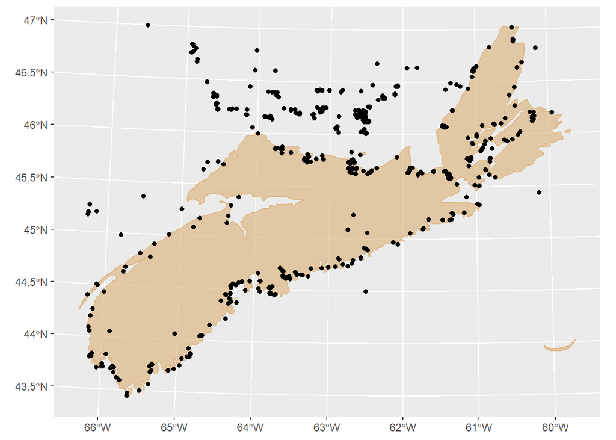

```r
crabssf <- crabs %>%
  st_as_sf(coords=c("decimalLongitude", "decimalLatitude"),
           crs=latlong) %>% # convert dataframe to sf object
  st_transform(maritimes_eqdc_proj) # transform back to eqdc

map +
  geom_sf(data=crabssf)
```

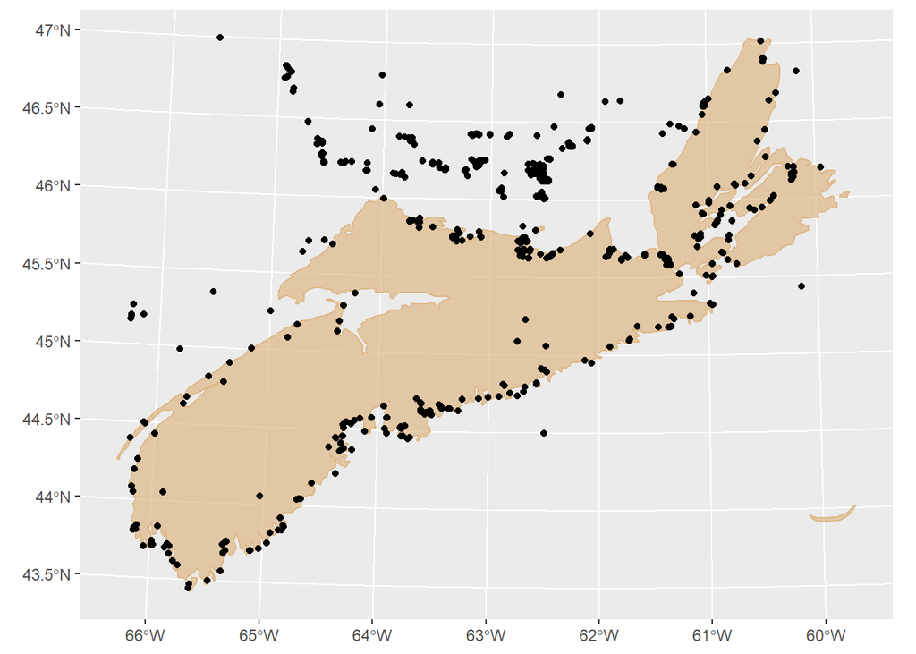

```r
ggplot(crabssf)+
  geom_sf(data=NS, fill="burlywood", colour="burlywood", alpha=0.7) +
  geom_sf()
```

Hosted at https://barefooted23.github.io/SWC_example/green_crab_report_JCN.html